# MA589 Project 5

Wenbin Teng

November 15, 2018

1.A genome can have a number of alterations to its DNA sequence. A common type of alteration is a $copy$ $number$ $variation$: some regions might have been $amplified$ or $deleted$. To measure possible changes in copy number, we can collect data from a comparative genomic hybridization (CGH) array. Roughly, for each probe $i$ in the array that corresponds to a position in a genomic sequence we measure $Y_i$, the log of the ratio between the copy number of an individual at position $i$ and a reference for a normal copy number.

Suppose you have a simple CGH array with only $n = 200$ probes. You decide to model the states of each probe as “deleted” (state 1), “normal” (state 2), and “duplicated” (state 3), and set a Markov chain for the transitions between states with probabilities

(a)Using the forward algorithm, compute $\log\mathbf{P}(Y)$

```r
LOGEPS <- log(.Machine$double.eps / 2)
lse <- function (x) {
  m <- max(x); x <- x - m
  m + log(sum(exp(x[x > LOGEPS])))
}
# normal log-liklihood function
logE <- function(yi,ns){
  matrix(c(dnorm(yi, -1, .7, log = TRUE),dnorm(yi,0,.5,log=TRUE),dnorm(yi,1,.7, log = TRUE)), nrow = ns, byrow = T)
}
# forward function
forward <- function (s, logI, logP) {
  n <- length(s); ns <- length(logI) # = nrow(logE) = nrow(logP)
  f <- matrix(nrow = n, ncol = ns)
  logE1 <- -logE(s[1], ns)
  f[1,] <- logI + logE1[,1]
  for (i in 2:n) # for each position in sequence
    for (j in 1:ns) # for each X_i
      f[i, j] <- lse(f[i - 1,] + logP[,j]) + logE(s[i],ns)[j]
  f
}
s <- cgh[,2]
logI <- log(c(0,1,0))
logP <- log(matrix(c(0.5,0.05,0,0.5,0.9,0.5,0,0.05,0.5),3,3))
cgha <- forward(s, logI, logP)
(cgh_a <- lse(cgha[200,]))
```

```
## [1] -195.8675
```

(b)Using the Viterbi algorithm, obtain the MAP estimate $\hat X$ for $X$. What is $\log \mathbf{P}(\hat X | Y )$?

```r
viterbi <- function (s, logI, logP) {
  n <- length(s); ns <- length(logI) # = nrow(logE) = nrow(logP)
  m <- matrix(nrow = n, ncol = ns) # maxima
  b <- matrix(nrow = n, ncol = ns) # backtrack pointers
  # recurse
  logE1 <- logE(s[1],ns)
  m[1,] <- logI + logE1[,1]
  for (i in 2:n) { # for each position in sequence
    for (j in 1:ns) { # for each X_i
      u <- m[i - 1,] + logP[,j]
      m[i, j] <- max(u) + logE(s[i],ns)[j]
      b[i - 1, j] <- which.max(u)
    }
  }
  # backtrack
  v <- numeric(n)
  v[n] <- which.max(m[n,]) # b[n]
  for (i in (n - 1):1)
    v[i] <- b[i, v[i + 1]]
  list(m = m, b = b, seq = v)
}

cghb <- viterbi(s,logI,logP)
(cgh_b <- lse(cghb$m[200,]))
```

```
## [1] -212.9045
```

By Bayes Rule:

$$\mathbf{P}(\hat{X}|Y)=\frac{\mathbf{P}(\hat{X},Y)}{\mathbf{P}(Y)}$$
$$\log\mathbf{P}(\hat{X}|Y)=\log\mathbf{P}(\hat{X},Y)-\log\mathbf{P}(Y)$$
Therefore,

```r
cgh_b - cgh_a
```

```
## [1] -17.03699
```

(c)Plot $Y$ as points and, for each probe $i$, the mean $\mu$ at $\hat{X}_i$. It’s better to connect the means using a solid, thicker line. Comment on the plot; for instance, does $\hat{X}$ seem to provide a reasonable fit? Are there regions that you would believe to differ from $\hat{X}$, say, as being amplified instead of normal according to $\hat{X}$?

```r
(mu <- ifelse(cghb$seq == 1,-1,ifelse(cghb$seq == 2,0,1)))
```

```
##   [1]  0  0  0  0  0  0  0 -1 -1 -1  0  0  0  0  0  0  0  0  0  0  0  0  0
##  [24]  0  0  0  0  0  0  0  0  1  1  1  1  1  1  1  1  1  0  0  0  0  0  0
##  [47]  0  0  0  0  0  0  0  0  0  0  0  0  0  0  0  0  0 -1 -1 -1 -1 -1 -1
##  [70]  0  0  0  0  0  0  0  0  0  0  0  0  0  0  0  0 -1 -1 -1 -1 -1 -1 -1
##  [93] -1 -1 -1 -1  0  0  0  0  0  0  0  0  0  0  0  0  0  0  0  0  0  0  0
## [116]  0  0  0  0  0  0  0  0  0  0  0  0  0  0 -1 -1 -1 -1 -1 -1 -1 -1  0
## [139]  0  0  0  0  0  0  0  0  0  0  0  0  0  0  0  0  0  1  1  1  1  1  0
## [162]  0  0  0  0  0  0  0  0  0  0  0  0  0  0  0  0  0  0  0  0  0  0  0
## [185]  0  0  0  0  0  0  0  0  0  0  0  0  0  0  0  0
```

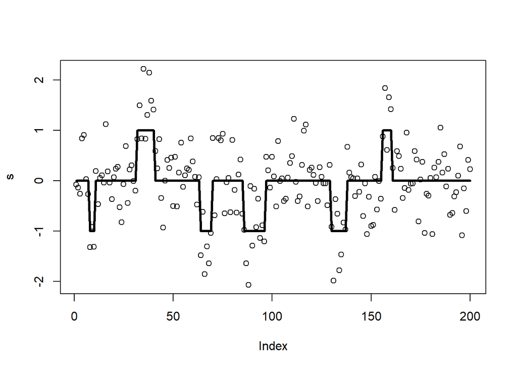

```r
{plot(s)
  lines(mu,lwd=3)}
```

(d)What is the probability that the last probe has a normal copy number given $Y$? How much more likely is it, again given $Y$ , for the last probe to be in a deleted region instead of a duplicated region?

```r
# d_1
exp(cgha[200,2]-cgh_a)
```

```
## [1] 0.9586747
```

```r
# d_2
exp(cgha[200,1]-cgh_a)-exp(cgha[200,3]-cgh_a)
```

```
## [1] -0.02121001
```

2.The human genome has genetic markers based on “single nucleotide polymorphisms” (SNPs) that can be used to assess the genetic risk of diseases. For instance, consider the $p = 11$ markers in file $\texttt{hla_snps.csv}$, where $\texttt{dbsnp}$ is an identifier and $\texttt{position}$ is the genomic position; these markers belong to the human leukocyte antigen (HLA) gene complex region, located in the short arm of chromosome 6. This complex encodes proteins that regulate the immune system and thus are connected to autoimmune disorders such as type I diabetes and celiac disease. File $\texttt{hla_study.csv}$ lists the results from a (hypothetical) study with $n = 100$ individuals: $\texttt{status}$ indicates disease status and the other columns count the number of allele copies of each HLA marker.

Let us assume that the disease status $Y_i$ of the $i$-th individual can be modeled using logistic regression with genotypes $\mathbf{x}_i = (x_{ij})_{j=1,...,p}, x_{ij}\in\big\{0, 1,2\big\}$:

$$Y_i|\beta_0,\beta\stackrel{iid}\sim\texttt{Bern}\big[\text{logit}^{-1}(\beta_0+\mathbf{x}_i^\top\beta)\big], i=1,...,n.$$

The main goal here is to infer the effect of each marker in the disease status. However, as it is common in these studies, we do not expect that every marker is actually associated with the status. To account for this, we perform $variable$ $selection$ and set

$$\beta_j|\theta_j\stackrel{iid}\sim N(0,(1-\theta_j)\tau_0^2+\theta_j\tau^2), j=1,...,p$$

$$\mathbf{P}(\theta)\propto \text{exp}\Bigg\{\frac{h}{2}\sum_{u=1}^p(2\theta_u-1)+\frac{1}{T}\sum_{(u,v)\in G}(2\theta_u-1)(2\theta_v-1)\Bigg\}$$

with $h=-100$ and $T=100$. To perform inference, we devise a Gibbs sampler to estimate $\mathbf{P}(\beta_0,\beta,\theta|Y)$.

(a)Show that, with $\sigma^2(\theta_j):=(1-\theta_j)\tau_0^2+\theta_j\tau^2$,

$$\mathbf{P}(\theta_j|\beta_0,\beta,\theta_{[-j]},Y)\propto(\sigma^2(\theta_j))^{-\frac{1}{2}}\exp\Bigg\{-\frac{\beta_j^2}{2\sigma^2(\theta_j)}+\theta_j\Bigg(h+\frac{2}{T}\sum_{v\in N_j}(2\theta_v-1)\Bigg)\Bigg\}$$

Remember to use logs when computing $\mathbf{P}(\theta_j=1|\beta_j,\theta_{N_j})$.

$$\log\mathbf{P}(\theta_j=1|\beta_j,\theta_{N_j})\propto-\log{\tau}-\frac{\beta_j^2}{2\tau^2}+h+\frac{2}{T}\sum_{v\in N_j}(2\theta_v-1)$$
$$\log\mathbf{P}(\theta_j=0|\beta_j,\theta_{N_j})\propto-\log{\tau_0}-\frac{\beta_j^2}{2\tau_0^2}$$
Let $\pi_j=\mathbf{P}(\theta_j=1|\beta_j,\theta_{N_j})$, then

$$\log\frac{\pi_j}{1-\pi_j}\propto \log\Bigg\{\frac{\tau_0}{\tau}\exp\Bigg[\frac{\beta_j^2}{2}\Bigg(\frac{1}{\tau_0^2}-\frac{1}{\tau^2}\Bigg)+h+\frac{2}{T}\sum_{v\in N_j}(2\theta_v-1)\Bigg]\Bigg\}$$
$$\text{logit}(\pi_j)\propto -2\log10+\frac{9999}{2}\beta_j^2-100+\frac{1}{50}\sum_{v\in N_j}(2\theta_v-1)$$
Sampling from $\beta_0|\beta,\theta,Y$ and $\beta_j|\beta_0,\beta_{[-j]},\theta,Y$ is trickier because there is no closed form expression for the distributions, but we can use Metropolis-Hastings steps.

For the proposal, we exploit a Laplace approximation to the conditional distribution: recall from lecture that we derived a routine $\texttt{step-laplace-mh}(\beta^{(t)};u,z,\phi,\beta_0,\omega)$ that draws the next move from $\beta^{(t)}$ in a Metropolis-Hastings sampler for

$$u_i|\beta\stackrel{iid}\sim\texttt{Bern}\big[\text{logit}^{-1}(z_i\beta+\phi_i)\big]\text{ and }\beta\sim N(\beta_0,\omega^{-1}).$$

(b)Suppose the chain is at the $t$-step and you’ve already sampled $\theta^{(t+1)}$ above. If $X$ is the design matrix with rows$\mathbf{x}_i$ and $j$-th column denoted by $X_j$, show that the remainder of the Gibbs cycle is

$$\beta_0^{(t+1)}=\texttt{step_laplace-mh}(\beta_0^{(t)};Y,\mathbf{1}_n,X\beta^{(t)},0,0)$$
with $\mathbf{1}_n$ a vector of ones of lengths $n$, and, for $j=1,...,p$,

$$\beta_j^{(t+1)}=\texttt{step-laplace-mh}(\beta_j^{(t)};Y,X_j,\mathbf{1}_n\beta_0^{(t+1)}+X_{1:(j-1)}\beta_{1:(j-1)}^{(t+1)}+X_{(j+1):p}\beta_{(j+1):p}^{(t)},0,(1-\theta_j^{(t+1)})/\tau_0^2+\theta_j^{(t+1)}/\tau^2).$$

We already know that:

$$Y_i|\beta_0\stackrel{iid}\sim\texttt{Bern}(\text{logit}^{-1}(\beta_0+\mathbf{x}^{\top}_i\beta))$$

Therefore, $Y|\beta_0\stackrel{iid}\sim\texttt{Bern}\big[\text{logit}^{-1}(\mathbf{1}_n\beta_0+X\beta)\big]$, where $\beta$ is a constant and $X\beta$ is the offset, so we have:

$$\beta_0^{(t+1)}=\texttt{step-laplace-mh}(\beta_0^{(t)};Y,\mathbf{1}_n,X\beta^{(t)},0,0)$$
Similarly, as we know that $Y|\beta\stackrel{iid}\sim\texttt{Bern}\big[\text{logit}^{-1}(\mathbf{1}_n\beta_0+X\beta)\big]$. Therefore,

$$Y|\beta_j\stackrel{iid}\sim\texttt{Bern}\big[\text{logit}^{-1}(X_j\beta_j+\mathbf{1}_n\beta_0+X_{1:(j-1)}\beta_{1:(j-1)}+X_{(j+1):p}\beta_{(j+1):p}\big]$$
The offset is: $\mathbf{1}_n\beta_0+X_{1:(j-1)}\beta_{1:(j-1)}+X_{(j+1):p}\beta_{(j+1):p}$

In addition, we know:

$$\beta_j|\theta_j\stackrel{iid}\sim N(0,(1-\theta_j)\tau_0^2+\theta_j\tau^2)$$
where $\omega^{-1}=(1-\theta_j)\tau_0^2+\theta_j\tau^2$, thus $\omega=\frac{(1-\theta_j)}{\tau_0^2}+\frac{\theta_j}{\tau^2}$

Based on Gibbs Sampling, we have:

$$\beta_1^{(t+1)}=\texttt{step-laplace-mh}(\beta_1^{(t)};Y,X_1,\mathbf{1}_n\beta_0^{(t+1)}+X_{2:p}\beta_{2:p}^{(t)},0,(1-\theta_1^{(t+1)})/\tau_0^2+\theta_1^{(t+1)}/\tau^2)\\
\beta_2^{(t+1)}=\texttt{step-laplace-mh}(\beta_2^{(t)};Y,X_2,\mathbf{1}_n\beta_0^{(t+1)}+X_{1}\beta_{1}^{(t+1)}+X_{3:p}\beta_{3:p}^{(t)},0,(1-\theta_2^{(t+1)})/\tau_0^2+\theta_2^{(t+1)}/\tau^2)\\
\beta_3^{(t+1)}=\texttt{step-laplace-mh}(\beta_3^{(t)};Y,X_3,\mathbf{1}_n\beta_0^{(t+1)}+X_{1:2}\beta_{1:2}^{(t+1)}+X_{4:p}\beta_{4:p}^{(t)},0,(1-\theta_3^{(t+1)})/\tau_0^2+\theta_3^{(t+1)}/\tau^2)\\
...\\
...\\
...\\
\beta_j^{(t+1)}=\texttt{step-laplace-mh}(\beta_j^{(t)};Y,X_j,\mathbf{1}_n\beta_0^{(t+1)}+X_{1:(j-1)}\beta_{1:(j-1)}^{(t+1)}+X_{(j+1):p}\beta_{(j+1):p}^{(t)},0,(1-\theta_j^{(t+1)})/\tau_0^2+\theta_j^{(t+1)}/\tau^2)$$

(c)Implement the hybrid Gibbs sampler using the HLA study: draw inferences for which markers should be selected and their effects (coefficients) and use histogram and/or density plots to summarize their distribution; assess convergence using trace and autocorrelation plots for $\log \mathbf{P}(\beta_0, \beta, \theta | Y )$ and selected coefficients, and compute scale reduction factors and effective sample size ratios.

```r
logit <- function (p) log(p / (1 - p))

inv_logit <- function (x) 1 / (1 + exp(-x))

LOGEPS <- log(.Machine$double.eps / 2)
log1pe <- function (x) {
  l <- ifelse(x > 0, x, 0)
  x <- ifelse(x > 0, -x, x)
  ifelse(x < LOGEPS, l, l + log1p(exp(x)))
}

sample_theta <- function(pos,theta0,beta) {
  p <- length(pos)
  for (j in 1:p) {
    thetav <- 0
    for (v in 1:p) {

      if (abs(pos[v]-pos[j])>0 && abs(pos[v]-pos[j])<50000) {
        thetav <- thetav + (2*theta0[v]-1)
      }
    }
    thres <- -2*log(10)+((9999/2)*beta[j]^2)-100 + 2/100 * thetav
    #print(thres)
    u <- runif(1)
    theta0[j] <- as.numeric(log(u/(1-u)) < thres)
  }
  theta0
}

log_posterior_beta0 <- function (beta, y, x, beta0) {
  eta <- rep(beta0,length(y)) + apply(x * beta,1,sum)
  sum(y * eta - log(1+exp(eta)))
}

log_posterior_beta <- function(beta, beta0, y, x, theta, tau0 = 0.01, tau = 1) {
  eta <- rep(beta0, length(y)) + apply(x * beta,1,sum)
  s <- (1-theta)/(tau0^2) + theta/(tau^2)
  sum(y * eta - log(1+exp(eta))) - 0.5 * s * beta^2
}


step_laplace_mh <- function (theta0, beta0, beta, y, x, pos, tau0=0.01,tau=1) {
  p <- length(pos)
  ns <- length(y)
  theta <- sample_theta(pos, theta0,beta)

  mu <- inv_logit(rep(beta0,ns)+apply(x * beta,1,sum))
  s_beta0 <- sqrt(1/sum(mu*(1-mu)))
  s_beta <- sqrt(1/(apply((mu*(1-mu)*x^2),2,sum)+(1-theta)/(tau0^2) + theta/(tau^2)))
  #print(s_beta)

  beta0c <- rnorm(1,beta0,s_beta0)
  #print(beta0c)
  mu0c <- inv_logit(rep(beta0c,ns)+apply(x * beta,1,sum))
  s_beta0c <- sqrt(1/sum(mu0c*(1-mu0c)))

  log_R0 <- log_posterior_beta0(beta,y,x,beta0c) + dnorm(beta0, beta0c, s_beta0c, log = TRUE)
         - (log_posterior_beta0(beta,y,x,beta0)  + dnorm(beta0c, beta0, s_beta0, log = TRUE))
  #print(log_R0)
  beta0c <- ifelse(log_R0 >= 0 || log(runif(1)) < log_R0, beta0c, beta0)

  betac <- rep(0,p)
  s_betac <- s_beta
  #betac[1] <- rnorm(1,beta[1],s_betac[1])
  #muc <- inv_logit(rep(beta0c,ns)+apply(x * c(betac[1],beta[2:p]),1,sum))
  #s_betac <- sqrt(1/(apply((muc*(1-muc)*x^2),2,sum)+(1-theta)/(tau0^2) + theta/(tau^2)))

  for (j in 1:(p-1)) {
    betac[j] <- rnorm(1,beta[j],s_betac[j])
    muc <- inv_logit(rep(beta0c,ns)+apply(x * c(betac[1:j],beta[(j+1):p]),1,sum))
    s_betac <- sqrt(1/(apply((muc*(1-muc)*x^2),2,sum)+(1-theta)/(tau0^2) + theta/(tau^2)))
  }
  #print(betac)
  log_R <- log_posterior_beta(beta=betac,beta0=beta0c,y=y,x=x,theta=theta) + dnorm(beta, betac, s_betac, log = TRUE)
         - (log_posterior_beta(beta=beta,beta0=beta0c,y=y,x=x,theta=theta) + dnorm(betac, beta, s_beta, log = TRUE))
  #print(log_R)
  for (j in 1:p) {
    betac[j] <- ifelse(log_R[j] >= 0 || log(runif(1)) < log_R[j], betac[j],beta[j])
  }
  list(theta, beta0c, betac)
}
```

Example for testing

```r
y <- study$status
x <- study[,-c(1)]
pos <- snps$position
beta0 <- 0
beta <- rep(0.145,length(pos))
theta0 <- rep(1,length(pos))

beta0.cur <- beta0;beta.cur <- beta;theta.cur <- theta0
for (t in 1:100) {
  laplace_result <- step_laplace_mh(theta.cur,beta0.cur,beta.cur,y,x,pos)
  theta.nxt <- laplace_result[[1]]
  beta0.nxt <- laplace_result[[2]]
  beta.nxt <- laplace_result[[3]]

  theta.cur <- theta.nxt;beta0.cur <- beta0.nxt;beta.cur <- beta.nxt
}
list(theta.cur,beta0.cur,beta.cur)
```

```
## [[1]]
##  [1] 0 1 1 0 1 0 1 1 1 1 1
##
## [[2]]
## [1] 0
##
## [[3]]
##  [1] 0.145 0.145 0.145 0.145 0.145 0.145 0.145 0.145 0.145 0.145 0.145
```